# Customizing R. Markdown outputs through GitHub branches

```r
## Loading the required packages
library(tidyverse)
library(here)
```

```r
library(rio)
library(cowplot)
library(ggpubr)
## create the required folders in the working directory
dir.create(here("data"), showWarnings = FALSE)
dir.create(here("scripts"), showWarnings = FALSE)
dir.create(here("figures"), showWarnings = FALSE)
dir.create(here("reports"), showWarnings = FALSE)
```

```r
## Import the datasets in the data subfolder
pacman::p_load(here)
file.copy(
  from = "C:/Users/userx/Downloads/cleaned_NHANES (1).csv",
  to = here("data", "cleaned_nhanes.csv"),
  overwrite = TRUE
)
```

```
## [1] TRUE
```

```r
cleaned_nhanes <- import(here("data", "cleaned_nhanes.csv"))

file.copy(
  from = "C:/Users/userx/Downloads/diet (1).csv",
  to = here("data", "diet (1).csv"),
  overwrite = TRUE
)
```

```
## [1] TRUE
```

```r
diet_data <- import(here("data", "diet (1).csv"))
```

## Exercise 1: Recreating and Combining Figures

### Individual figures

```r
library(ggplot2)
library(dplyr)

## Define the Okabe-Ito color palette first
okabe_ito_palette <- c("#E69F00", "#56B4E9", "#009E73", "#0072B2", "#D55E00", "#CC79A7", "#999999")

## Checking the labels
str(cleaned_nhanes$gender)
```

```
##  chr [1:29400] "Male" "Male" "Male" "Male" "Female" "Male" "Male" "Female" ...
```

```r
str(cleaned_nhanes$age_cat)
```

```
##  chr [1:29400] "60+" "40-59" "60+" "0-17" "60+" "40-59" "0-17" "60+" ...
```

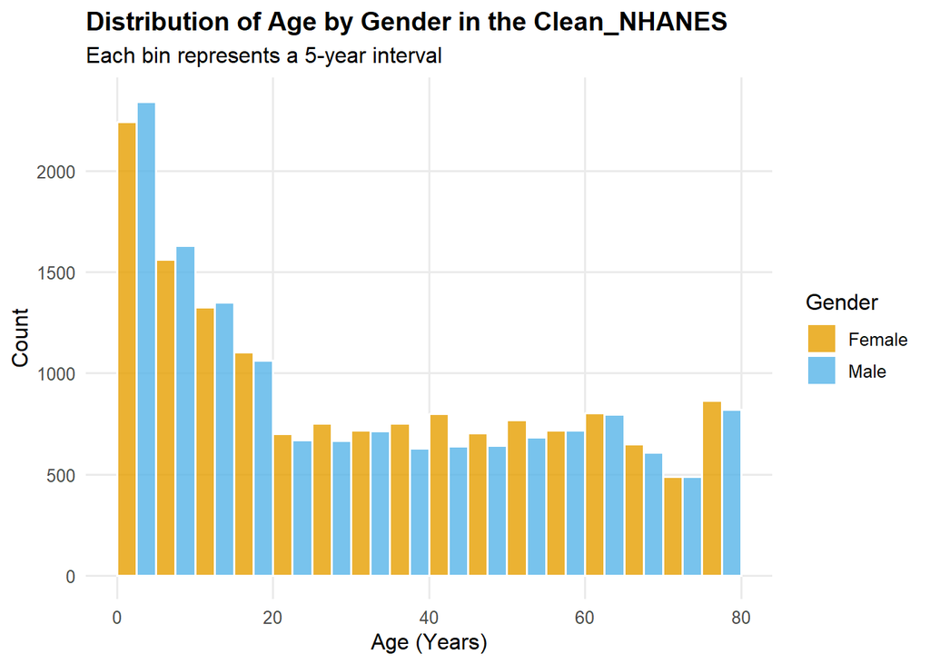

```r
## Figure 1: Histogram of age by gender
fig_1 <- ggplot(cleaned_nhanes, aes(x = age, fill = gender)) +
  geom_histogram(binwidth = 5, color = "white", boundary = 0, alpha = 0.8, position = "dodge") +
  scale_fill_manual(values = okabe_ito_palette) +
  labs(
    title = "Distribution of Age by Gender in the Clean_NHANES",
    subtitle = "Each bin represents a 5-year interval",
    x = "Age (Years)",
    y = "Count",
    fill = "Gender"
  ) +
  theme_minimal(base_size = 12) +
  theme(
    plot.title = element_text(face = "bold", size = 14),
    panel.grid.minor = element_blank()
  )
fig_1
```

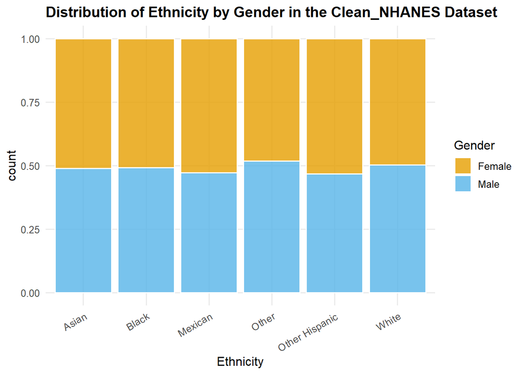

```r
## Figure 2: Bar chart of ethnicity by gender
fig_2 <- ggplot(cleaned_nhanes, aes(x = ethnicity_2, fill = gender)) +
  geom_bar(position = "fill", color = "white", alpha = 0.8) +
  scale_fill_manual(values = okabe_ito_palette) +
  labs(
    title = "Distribution of Ethnicity by Gender in the Clean_NHANES Dataset",
    x = "Ethnicity",
    y = "count",
    fill = "Gender"
  ) +
  theme_minimal(base_size = 12) +
  theme(
    plot.title = element_text(face = "bold", size = 14),
    axis.text.x = element_text(angle = 30, hjust = 1),
    panel.grid.minor = element_blank()
  )

# Display the plot
fig_2
```

### Combined Figures

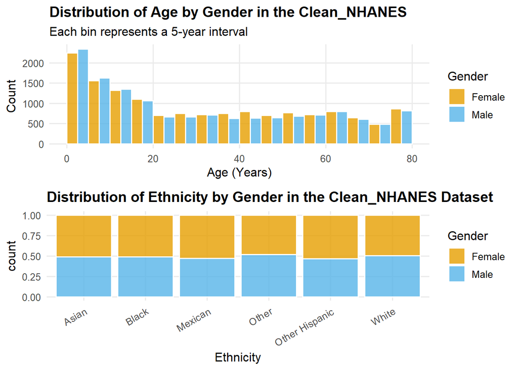

```r
## Combining fig_1 and fig_2 using cowplot
plot_grid(
  fig_1, fig_2,
  rel_heights = c(1, 1),
  nrow = 2,
  ncol = 1
)
```

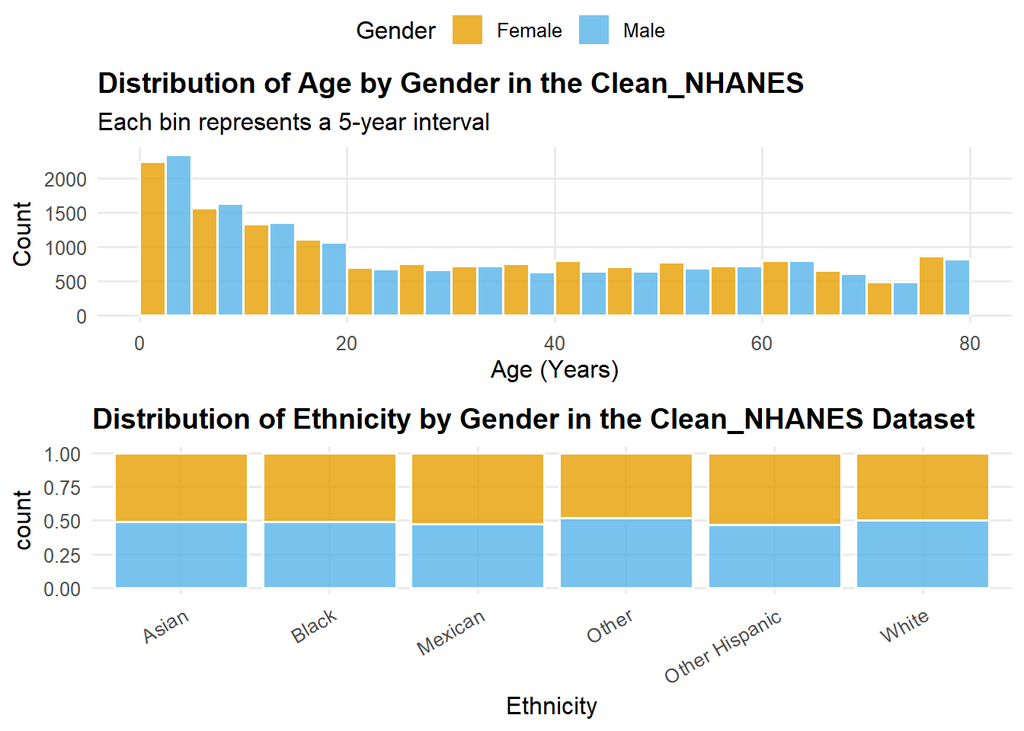

```r
## Combining fig_1 and fig_2 using ggarrange
ggarrange(
  fig_1, fig_2, nrow = 2, ncol = 1,
  common.legend = TRUE, legend = "top"
)
```

## Exercise 2: Visualizing Key Characteristics

### Interactive dataset explorer

```r
library(DT)
library(ggplot2)
library(dplyr)

## Interactive Dataset Explorer using DT package
datatable(
  cleaned_nhanes,
  options = list(pageLength = 10, scrollX = TRUE),
  caption = "Interactive Cleaned NHANES Dataset Explorer"
)
```

|  | V1 | patient_id | bp_comment | systolic_bp_1 | diastolic_bp_1 | systolic_bp_2 | diastolic_bp_2 | systolic_bp_3 | diastolic_bp_3 | systolic_bp_4 | diastolic_bp_4 | wave_id | gender | age | ethnicity_1 | ethnicity_2 | education | marital_status | family_size | family_income | age_cat |
| --- | --- | --- | --- | --- | --- | --- | --- | --- | --- | --- | --- | --- | --- | --- | --- | --- | --- | --- | --- | --- | --- |
| 1 | 1 | 73557 |  | 122 | 72 | 114 | 76 | 102 | 74 |  |  | 2015 | Male | 69 | Black | Black | High School | Separated | 3 | $15,000 - $19,999 | 60+ |
| 2 | 2 | 73558 |  | 156 | 62 | 160 | 80 | 156 | 42 |  |  | 2015 | Male | 54 | White | White | High School | Married | 4 | $35,000 - $44,999 | 40-59 |
| 3 | 3 | 73559 |  | 140 | 90 | 140 | 76 | 146 | 80 |  |  | 2015 | Male | 72 | White | White | Some college | Married | 2 | $65,000 - $74,999 | 60+ |
| 4 | 4 | 73560 |  | 108 | 38 | 102 | 34 | 104 | 38 |  |  | 2015 | Male | 9 | White | White |  |  | 4 | $55,000 - $64,999 | 0-17 |
| 5 | 5 | 73561 |  | 136 | 86 | 134 | 88 | 142 | 86 |  |  | 2015 | Female | 73 | White | White | College graduate | Married | 2 | $100,000 or more | 60+ |
| 6 | 6 | 73562 |  | 160 | 84 | 158 | 82 | 154 | 80 |  |  | 2015 | Male | 56 | Mexican | Mexican | Some college | Divorced | 1 | $55,000 - $64,999 | 40-59 |
| 7 | 7 | 73563 |  |  |  |  |  |  |  |  |  | 2015 | Male | 0 | White | White |  |  | 3 | $100,000 or more | 0-17 |
| 8 | 8 | 73564 |  | 118 | 80 | 124 | 80 | 126 | 82 |  |  | 2015 | Female | 61 | White | White | College graduate | Widowed | 1 | $65,000 - $74,999 | 60+ |
| 9 | 9 | 73566 |  | 128 | 74 | 124 | 72 | 114 | 72 |  |  | 2015 | Female | 56 | White | White | High School | Divorced | 7 or more | $15,000 - $19,999 | 40-59 |
| 10 | 10 | 73567 |  | 140 | 78 | 142 | 78 | 142 | 76 |  |  | 2015 | Male | 65 | White | White | 9-11th grade | Widowed | 1 | $10,000 - $14,999 | 60+ |

[output cut: 29390 more lines]

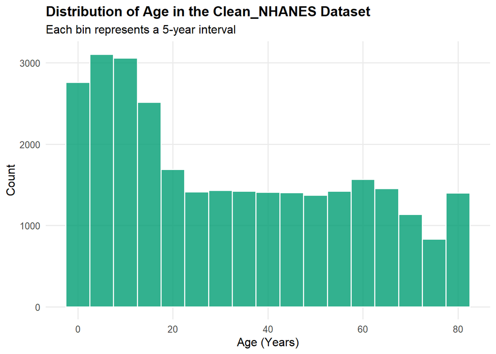

```r
visual_age <- ggplot(cleaned_nhanes, aes(x = age)) +
  geom_histogram(binwidth = 5, fill = "#009E73", color = "white", alpha = 0.8) +
  labs(
    title = "Distribution of Age in the Clean_NHANES Dataset",
    subtitle = "Each bin represents a 5-year interval",
    x = "Age (Years)",
    y = "Count"
  ) +
  theme_minimal(base_size = 12) +
  theme(
    plot.title = element_text(face = "bold", size = 14),
    panel.grid.minor = element_blank()
  )

visual_age
```

```r
## checking for missingness
sum(is.na(cleaned_nhanes$age))
```

```
## [1] 0
```

```r
sum(cleaned_nhanes$age, na.rm = TRUE)
```

```
## [1] 956149
```

### Age distribution

For the variable age, the distribution shows a right-skewed pattern. The age of the patients range from 0 to 80 years with a median age of 28 years and average age of 32.5 years. There are no missing values in the variable age.

### Gender distribution

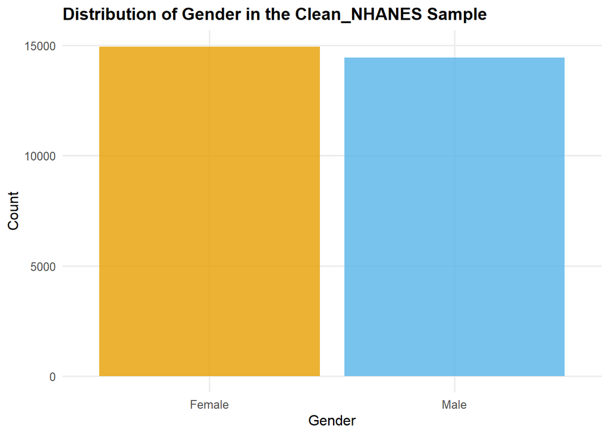

```r
## Visualising Gender
visual_gender <- ggplot(cleaned_nhanes, aes(x = gender, fill = gender)) +
  geom_bar(alpha = 0.8) +
  scale_fill_manual(values = okabe_ito_palette) +
  labs(
    title = "Distribution of Gender in the Clean_NHANES Sample",
    x = "Gender",
    y = "Count",
    fill = "Gender"
  ) +
  theme_minimal(base_size = 12) +
  theme(
    plot.title = element_text(face = "bold", size = 14),
    legend.position = "none",
    panel.grid.minor = element_blank()
  )

visual_gender
```

```r
## checking for missingness
sum(is.na(cleaned_nhanes$gender))
```

```
## [1] 0
```

```r
table(cleaned_nhanes$gender)
```

```
##
## Female   Male
##  14948  14452
```

Among the patients, 14,948 (50.8%) are female and 14,452 (49.2%) are male, and there are no missing values in the variable gender.

### Ethnicity distributions

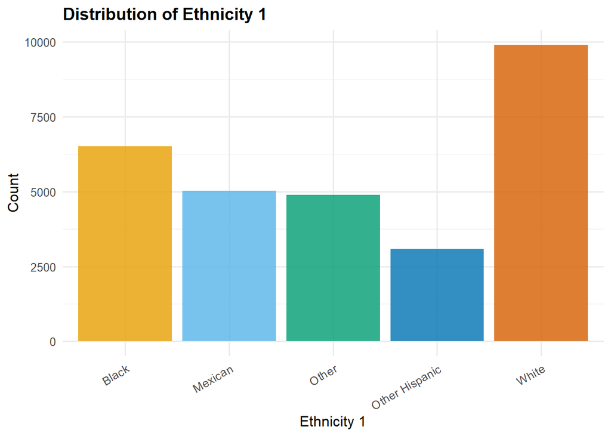

```r
## Distribution of Ethnicity 1
visual_ethinicity_1 <- ggplot(cleaned_nhanes, aes(x = ethnicity_1, fill = ethnicity_1)) +
  geom_bar(alpha = 0.8) +
  scale_fill_manual(values = okabe_ito_palette) +
  labs(
    title = "Distribution of Ethnicity 1",
    x = "Ethnicity 1",
    y = "Count",
    fill = "Ethnicity1"
  ) +
  theme_minimal(base_size = 12) +
  theme(
    plot.title = element_text(face = "bold", size = 14),
    axis.text.x = element_text(angle = 30, hjust = 1),
    legend.position = "none"
  )

visual_ethinicity_1
```

```r
## Checking for missingness
sum(is.na(cleaned_nhanes$ethnicity_1))
```

```
## [1] 0
```

```r
table(cleaned_nhanes$ethnicity_1)
```

```
##
##          Black        Mexican          Other Other Hispanic          White
##           6511           5018           4893           3088           9890
```

### Distribution of first category of ethnicity1

The total number of participants is 29,400, of these the majority are white 9,890 (33.6%) followed by black participants 6,511 (22.2%). The lowest category of participants is hispanic 3,088 (10.5%). This category of ethnicity has no missing values.

### Save figures and select an ethnicity variable

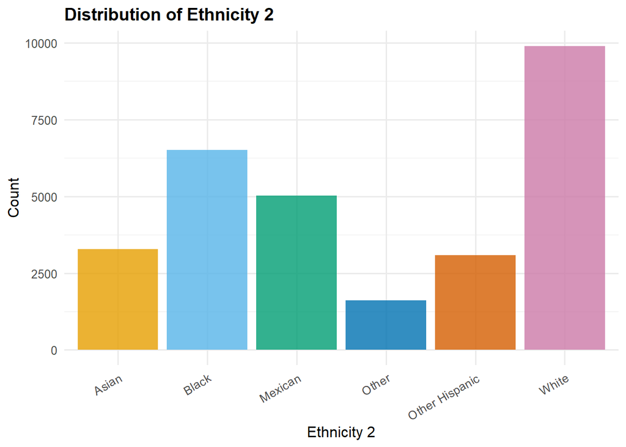

```r
visual_ethinicity_2 <- ggplot(cleaned_nhanes, aes(x = ethnicity_2, fill = ethnicity_2)) +
  geom_bar(alpha = 0.8) +
  scale_fill_manual(values = okabe_ito_palette) +
  labs(
    title = "Distribution of Ethnicity 2",
    x = "Ethnicity 2",
    y = "Count",
    fill = "Ethnicity2"
  ) +
  theme_minimal(base_size = 12) +
  theme(
    plot.title = element_text(face = "bold", size = 14),
    axis.text.x = element_text(angle = 30, hjust = 1),
    legend.position = "none"
  )

visual_ethinicity_2
```

```r
## checking for missingness
ethinicity2_table <- table(cleaned_nhanes$ethnicity_2, useNA = "ifany")

data.frame(
  ethin = names(ethinicity2_table),
  Frequency = as.vector(ethinicity2_table),
  Percentage = round(as.vector(prop.table(ethinicity2_table) * 100), 1)
)
```

```
##            ethin Frequency Percentage
## 1          Asian      3284       11.2
## 2          Black      6511       22.1
## 3        Mexican      5018       17.1
## 4          Other      1609        5.5
## 5 Other Hispanic      3088       10.5
## 6          White      9890       33.6
```

```r
summary(cleaned_nhanes$age)
```

```
##    Min. 1st Qu.  Median    Mean 3rd Qu.    Max.
##    0.00   10.00   28.00   32.52   54.00   80.00
```

```r
table(cleaned_nhanes$gender)
```

```
##
## Female   Male
##  14948  14452
```

```r
table(cleaned_nhanes$ethnicity_1)
```

```
##
##          Black        Mexican          Other Other Hispanic          White
##           6511           5018           4893           3088           9890
```

```r
table(cleaned_nhanes$ethnicity_2)
```

```
##
##          Asian          Black        Mexican          Other Other Hispanic
##           3284           6511           5018           1609           3088
##          White
##           9890
```

```r
## Using "ggsave" to save all plots in the figure subfolder in the working directory
ggsave(
  filename = "age_distribution_plot.png",
  plot = visual_age,
  path = here("figures"),
  width = 8,
  height = 6
)

ggsave(
  filename = "gender_distribution_plot.png",
  plot = visual_gender,
  path = here("figures"),
  width = 8,
  height = 6
)

ggsave(
  filename = "Ethinicity1_distribution_plot.png",
  plot = visual_ethinicity_1,
  path = here("figures"),
  width = 8,
  height = 6
)

ggsave(
  filename = "Ethinicity2_distribution_plot.png",
  plot = visual_ethinicity_2,
  path = here("figures"),
  width = 8,
  height = 6
)
```

```r
## choosing from the two categories of ethnicity
str(cleaned_nhanes$ethnicity_1)
```

```
##  chr [1:29400] "Black" "White" "White" "White" "White" "Mexican" "White" ...
```

```r
str(cleaned_nhanes$ethnicity_2)
```

```
##  chr [1:29400] "Black" "White" "White" "White" "White" "Mexican" "White" ...
```

```r
table(cleaned_nhanes$ethnicity_1)
```

```
##
##          Black        Mexican          Other Other Hispanic          White
##           6511           5018           4893           3088           9890
```

```r
table(cleaned_nhanes$ethnicity_2)
```

```
##
##          Asian          Black        Mexican          Other Other Hispanic
##           3284           6511           5018           1609           3088
##          White
##           9890
```

```r
sum(is.na(cleaned_nhanes$ethnicity_1))
```

```
## [1] 0
```

```r
sum(is.na(cleaned_nhanes$ethnicity_2))
```

```
## [1] 0
```

### Decision

After analysing the two categories, I decided to keep Ethnicity2 category and drop category 1. Whereas both categories have an equal number of observations (29,400), ethnicity1 has 5 categories while ethnicity2 has 6 categories. Ethnicity2 adds on the “asian” category which makes it more representative than category 1.

```r
## keeping Ethnicity 2 and dropping Ethnicity 1
cleaned_nhanes <- cleaned_nhanes %>%
  select(-ethnicity_1)
names(cleaned_nhanes)
```

```
##  [1] "V1"             "patient_id"     "bp_comment"     "systolic_bp_1"
##  [5] "diastolic_bp_1" "systolic_bp_2"  "diastolic_bp_2" "systolic_bp_3"
##  [9] "diastolic_bp_3" "systolic_bp_4"  "diastolic_bp_4" "wave_id"
## [13] "gender"         "age"            "ethnicity_2"    "education"
## [17] "marital_status" "family_size"    "family_income"  "age_cat"
```

## Exercise 3: Improving the ggplot Figure

### Points that need improvement in your colleague’s figure and how I will improve them.

In my colleague’s plot, there’s no title; I will create a plot and give a title “Participant’s Weight Change from Baseline weight”. This helps the audience grasp the objective of the plot at first glance.

The objective of the study is to show how each participant’s weight has changed over time from the baseline weight. My colleague’s plot doesn’t show baseline weight. I will create a baseline weight (at 0) and show how each participant deviates from it. Those above it have had a weight gain and those below it have had a weight loss.

### Calculate and plot change from baseline

```r
## To determine how each participant's weight has changed over time in comparison to the baseline weight
change_in_weight <- diet_data %>%
  group_by(Participant) %>%
  arrange(Week) %>%
  mutate(
    baseline_weight = Weight[Week == 0][1],
    change_from_baseline = Weight - baseline_weight
  ) %>%
  ungroup()

head(change_in_weight)
```

```
## # A tibble: 6 × 5
##    Week Participant Weight baseline_weight change_from_baseline
##   <int>       <int>  <dbl>           <dbl>                <dbl>
## 1     0           1   95.9            95.9                    0
## 2     0           2   95.8            95.8                    0
## 3     0           3   69.5            69.5                    0
## 4     0           4   91.4            91.4                    0
## 5     0           5   83.8            83.8                    0
## 6     0           6   80.2            80.2                    0
```

### From the results, 0 means there was no change in weight after following the diet, negative means there was a loss in weight and positive means there was a gain in weight.

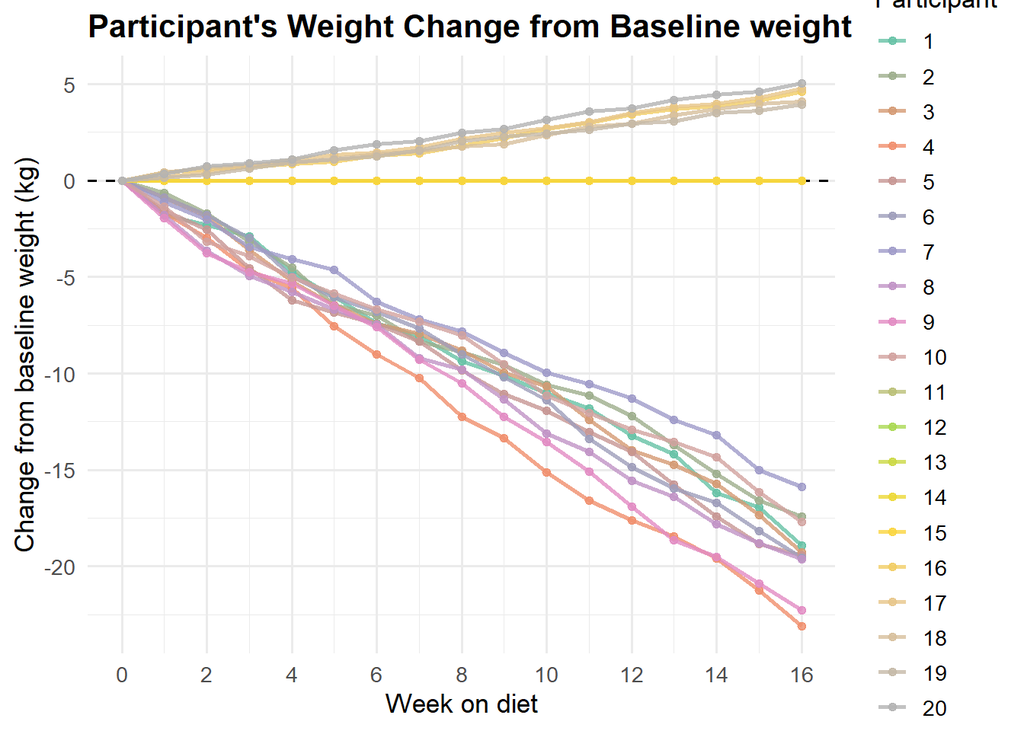

```r
## Plotting the right spaghetti plot to show each participant's weight has changed
library(RColorBrewer) # Required for ColorBrewer palettes

plot_data <- change_in_weight %>%
  group_by(Participant) %>%
  arrange(Week, .by_group = TRUE) %>%
  mutate(
    baseline_weight = first(Weight[Week == 0]),
    change_from_baseline = Weight - baseline_weight
  ) %>%
  ungroup()

# 1. Generate a color palette using RColorBrewer
num_participants <- n_distinct(plot_data$Participant)
my_colors <- colorRampPalette(brewer.pal(8, "Set2"))(num_participants)

# 2. Build the plot with individual distinct colors
ggplot(
  plot_data,
  aes(
    x = Week,
    y = change_from_baseline,
    group = Participant,
    color = factor(Participant)
  )
) +
  geom_hline(
    yintercept = 0,
    linetype = "dashed",
    color = "black",
    linewidth = 0.7
  ) +
  geom_line(
    linewidth = 1,
    alpha = 0.8
  ) +
  geom_point(
    size = 1.6,
    alpha = 0.8
  ) +
  scale_color_manual(values = my_colors) +
  scale_x_continuous(
    breaks = seq(0, 16, by = 2)
  ) +
  labs(
    title = "Participant's Weight Change from Baseline weight",
    x = "Week on diet",
    y = "Change from baseline weight (kg)",
    color = "Participant"
  ) +
  theme_minimal(base_size = 13) +
  theme(
    plot.title = element_text(face = "bold"),
    legend.position = "right"
  )
```

## Exercise 4: Exploring Relationships Through Visualizations

### The objective of this part is to explore relationships between age, gender, and systolic blood pressure (SBP) using effective visual storytelling.

```r
## Averaging the systolic blood pressure variables
cleaned_nhanes <- cleaned_nhanes %>%
  mutate(
    avg_sbp = rowMeans(
      select(., systolic_bp_1, systolic_bp_2, systolic_bp_3, systolic_bp_4),
      na.rm = TRUE
    ),
    avg_sbp = ifelse(is.nan(avg_sbp), NA, avg_sbp)
  )

## Create a new categorical variable that classifies individuals based on their average SBP
cleaned_nhanes <- cleaned_nhanes %>%
  mutate(
    sbp_category = case_when(
      avg_sbp < 120 ~ "Normal",
      avg_sbp >= 120 & avg_sbp < 130 ~ "Elevated",
      avg_sbp >= 130 & avg_sbp < 140 ~ "Stage 1 hypertension",
      avg_sbp >= 140 ~ "Stage 2 hypertension",
      TRUE ~ NA_character_
    ),
    sbp_category = factor(
      sbp_category,
      levels = c("Normal", "Elevated", "Stage 1 hypertension", "Stage 2 hypertension")
    )
  )

## Use the filter() function to create a new dataset that includes only individuals with non-missing values
nhanes_clean <- cleaned_nhanes %>%
  filter(!is.na(age_cat) & !is.na(gender) & !is.na(avg_sbp))

names(nhanes_clean)
```

```
##  [1] "V1"             "patient_id"     "bp_comment"     "systolic_bp_1"
##  [5] "diastolic_bp_1" "systolic_bp_2"  "diastolic_bp_2" "systolic_bp_3"
##  [9] "diastolic_bp_3" "systolic_bp_4"  "diastolic_bp_4" "wave_id"
## [13] "gender"         "age"            "ethnicity_2"    "education"
## [17] "marital_status" "family_size"    "family_income"  "age_cat"
## [21] "avg_sbp"        "sbp_category"
```

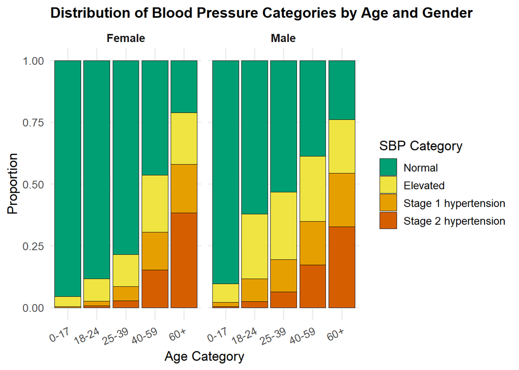

```r
## Using facet_wrap() to investigate how hypertension varies across age and gender
ggplot(nhanes_clean, aes(x = age_cat, fill = sbp_category)) +
  geom_bar(position = "fill", color = "black", linewidth = 0.3) +
  facet_wrap(~ gender) +
  scale_fill_manual(
    values = c(
      "Normal"              = "#009E73", # Green
      "Elevated"            = "#F0E442", # Yellow
      "Stage 1 hypertension" = "#E69F00", # Orange
      "Stage 2 hypertension" = "#D55E00"  # Red-Orange
    )
  ) +
  labs(
    title = "Distribution of Blood Pressure Categories by Age and Gender",
    x = "Age Category",
    y = "Proportion",
    fill = "SBP Category"
  ) +
  theme_minimal(base_size = 13) +
  theme(
    plot.title = element_text(face = "bold", size = 14),
    plot.subtitle = element_text(color = "gray30", size = 11),
    axis.text.x = element_text(angle = 25, hjust = 1),
    legend.position = "right",
    panel.grid.minor = element_blank(),
    strip.text = element_text(face = "bold", size = 11)
  )
```

```r
## Use of sample size comparison
old_dataset <- nrow(cleaned_nhanes)
new_dataset <- nrow(nhanes_clean)
n_removed <- old_dataset - new_dataset
percent_removed <- 100 * n_removed / old_dataset

sample_sizes <- data.frame(
  Dataset = c("old sample", "new sample"),
  Observations = c(old_dataset, new_dataset)
)

sample_sizes
```

```
##      Dataset Observations
## 1 old sample        29400
## 2 new sample        21604
```

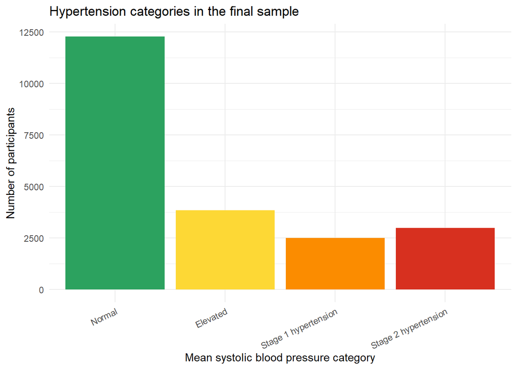

```r
## Plot showing hypertension categories
sbp_colors <- c(
  "Normal" = "#2CA25F",
  "Elevated" = "#FDD835",
  "Stage 1 hypertension" = "#FB8C00",
  "Stage 2 hypertension" = "#D7301F"
)

plot_sbp <- ggplot(
  nhanes_clean,
  aes(x = sbp_category, fill = sbp_category)
) +
  geom_bar() +
  scale_fill_manual(values = sbp_colors, drop = FALSE) +
  labs(
    title = "Hypertension categories in the final sample",
    x = "Mean systolic blood pressure category",
    y = "Number of participants"
  ) +
  theme_minimal() +
  theme(
    legend.position = "none",
    axis.text.x = element_text(angle = 25, hjust = 1)
  )

plot_sbp
```

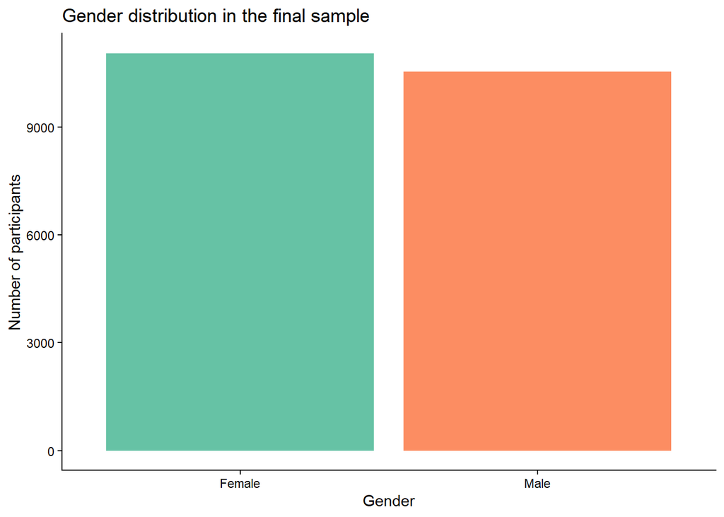

```r
## Plot of gender distribution
p_gender <- ggplot(nhanes_clean, aes(x = gender, fill = gender)) +
  geom_bar() +
  labs(
    title = "Gender distribution in the final sample",
    x = "Gender",
    y = "Number of participants"
  ) +
  scale_fill_brewer(palette = "Set2") +
  theme_classic() +
  theme(legend.position = "none")

p_gender
```

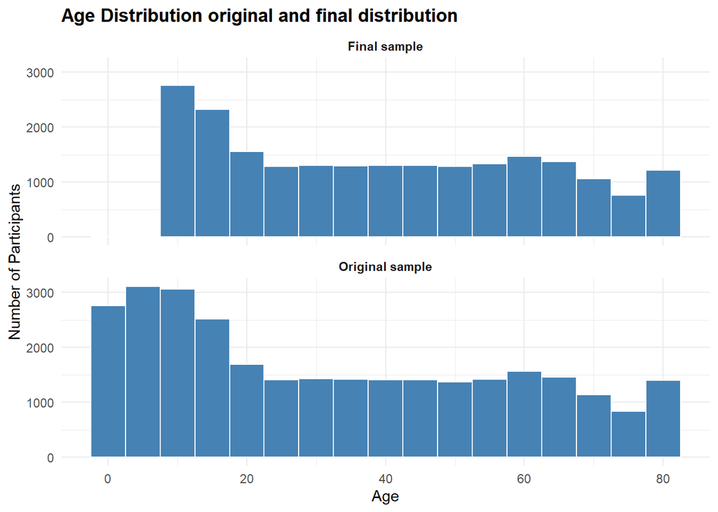

```r
## Compare original sample age distribution to final sample age distribution
library(dplyr)
library(ggplot2)

age_comparison <- bind_rows(
  cleaned_nhanes %>%
    filter(!is.na(age)) %>%
    select(age) %>%
    mutate(sample = "Original sample"),

  nhanes_clean %>%
    filter(!is.na(age)) %>%
    select(age) %>%
    mutate(sample = "Final sample")
)

age_comparison_plot2 <- ggplot(
  age_comparison,
  aes(x = age)
) +
  geom_histogram(
    binwidth = 5,
    fill = "steelblue",
    color = "white"
  ) +
  facet_wrap(~ sample, ncol = 1) +
  labs(
    title = "Age Distribution original and final distribution",
    x = "Age",
    y = "Number of Participants"
  ) +
  theme_minimal() +
  theme(
    plot.title = element_text(face = "bold"),
    strip.text = element_text(face = "bold")
  )

age_comparison_plot2
```

### A short report

To analyze systolic blood pressure (SBP), I calculated an average for each participant using up to four available readings. Participants missing all four readings were excluded, along with anyone missing age or gender data.

Younger participants are more commonly classified as having normal or elevated blood pressure, whereas older participants show a greater proportion of Stage 1 and Stage 2 hypertension. These age-related patterns are visible in both genders, although the proportions may differ somewhat between males and females within particular age groups.

Overall, the visualizations suggest an association between increasing age and higher SBP in this cohort.